# Homework 1

Esben Kran

4/6/2022

# Statistical signal processing

```r
pacman::p_load(tidyverse, ggplot)
```

## 1.1.1

In a radar system an estimator of round trip delay $\tau_0$ has the PDF $\hat \tau_0 \sim N(\tau_0,\sigma_{\hat\tau_0}^2)$, where $\tau_0$ is the true value. If the range is to be estimated, propose an estimator $R$ and find its PDF. Next determine the standard deviation $\sigma_{\hat\tau_0}$ so that 99% of the time the range estimate will be within 100 m of the true value. Use $c=3\cdot 10^8 m/s$ for the speed of electromagnetic propagation.

The estimator for R is
$$R~\dfrac{c\cdot N(\tau_0, \sigma^2_{\hat \tau_0})}{2}$$

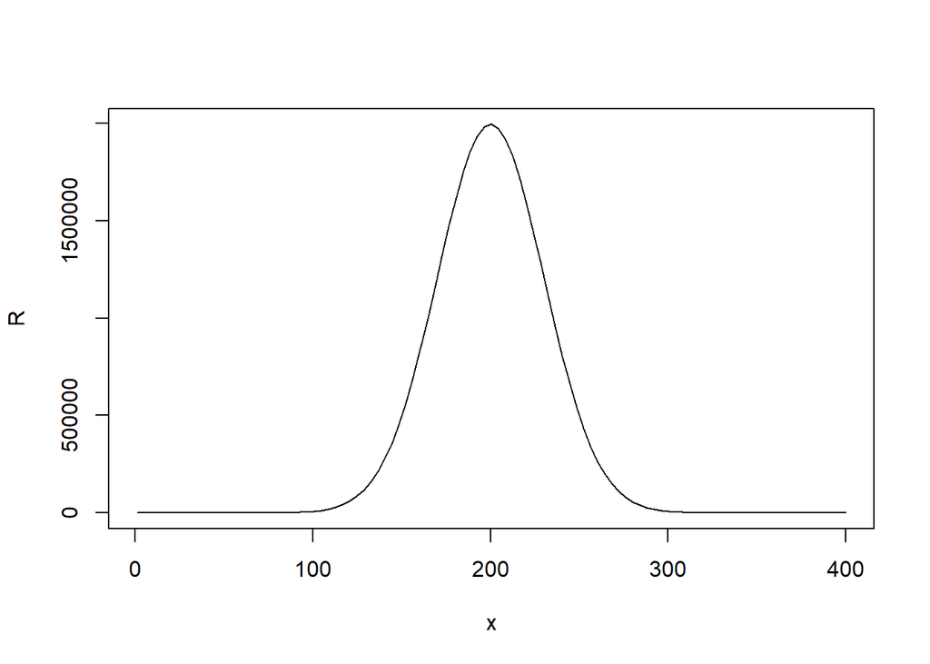

```r
c <- 3 * 10^8
range_lim = 100
sigma = 30
tau = 200

# Defining range estimator:
R <- function(x) (c*dnorm(x, tau, sigma)) / 2
plot(R, xlim=c(1,400))
```

```r
# Not sure about determining SD for 99% range estimate \in [-100, 100]
```

## 1.1.4

It is desired to estimate the value of a DC level A in WGN or
$$x[n]=A+w[n]$ where $n=0,1,...,N-1$$
Where $w[n]$ is zero mean and uncorrelated, and each sample has variance $\sigma^2=1$. Consider the two estimators:
$$\hat A = \dfrac{1}{N}\sum^{N-1}_{n=0}{x[n]}$$
$$\overline A=\dfrac{1}{N+2}\left(2x[0]+\sum^{N-1}_{n=1}{x[n]+2x[N-1]}\right)$$
Which one is better? Does it depend on the value of A?

Run M experiments to see difference between the two estimators and analyse error. Based on what we can see here, **the estimator $A_1$ is always better than estimator $A_2$**.

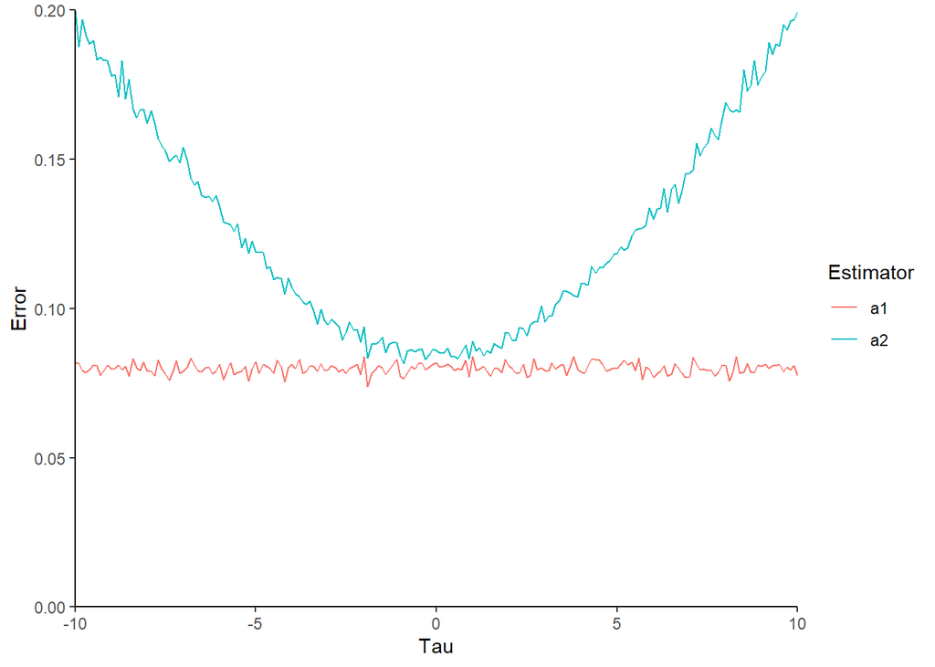

```r
test_range = seq(-10, 10, 0.1)
samples = 100
M = 1000

a1 <- function(x) mean(x)
a2 <- function(x) (1/(length(x)+2))*(2*x[1]+sum(x)+2*x[length(x)-1])

data.frame(
    m = lapply(1:M, function(m) rep(m, length(test_range) * samples)) %>% unlist,
    mu = lapply(1:M, function(m) lapply(test_range, function(i) rep(i, samples)) %>% unlist) %>% unlist,
    x = lapply(1:M, function(m) lapply(test_range, function(i) rnorm(samples, i, 1)) %>% unlist) %>% unlist
  ) %>%
  group_by(mu, m) %>%
  summarise(
    a1 = abs(a1(x)-mu),
    a2 = abs(a2(x)-mu)
  ) %>%
  group_by(mu) %>%
  summarise(
    a1 = mean(a1),
    a2 = mean(a2)
  ) %>%
  unique() %>%
  pivot_longer(c(a1, a2)) %>%
  ggplot() +
  aes(mu, value, color = name) +
  geom_line() +
  theme_classic() +
  labs(
    x = "Tau",
    y = "Error",
    color = "Estimator"
  ) +
  coord_cartesian(ylim=c(0, 0.2), expand=F)
```

## 1.1.2

An unknown parameter $O$ influences the outcome of an experiment which is modeled by the random variable x. The PDF of x is
$$p(x;O)=\dfrac{1}{\sqrt{2\pi}}exp\left[-\dfrac{1}{2}(x-O)^2\right]$$
A series of experiments is performed, and x is found to always be in the interval $[97,103]$. As a result, the investigator concludes that $O$ must have been 100. Is this assertion correct?

```r
a <- 100
x <- rnorm(1000, 100, 1)
mean_x <- mean(x)
range_x <- max(x) - min(x)

paste(
  "**[1.1.2] Sampling a 1000 times with an A of",
  a,
  "gives a mean of",
  mean_x,
  "with range",
  min(x),
  "to",
  max(x),
  "of",
  range_x,
  "which indicates that the",
  "investigator is correct.**"
)
```

```
## [1] "**[1.1.2] Sampling a 1000 times with an A of 100 gives a mean of 99.9730684183665 with range 96.8803859883147 to 103.187244282681 of 6.30685829436646 which indicates that the investigator is correct.**"
```

## 6

Suppose $x\sim N(5,2)$ and $y\sim 2x+4$. Find $E(y)$, $var(y)$, and the PDF $p_y(y)$.

Expected value (mean(y)):

```r
beta_1 <- function(x)
  dnorm(x, 5, 2)
f <- function(x)
  1/abs(2) * beta_1((x-4)/2)

weighted.mean(seq(-1e2, 1e2, 1e-2), f(seq(-1e2, 1e2, 1e-2)))
```

```
## [1] 14
```

Variance from the sampled distribution:

```r
x <- seq(0, 50, 0.1)
px <- f(seq(0, 50, 0.1))
draws <- sample(x, size = 5000, replace = TRUE, prob = px)

var(draws)
```

```
## [1] 15.31712
```

The PDF of y with $a$ multiplied into $beta_1$:

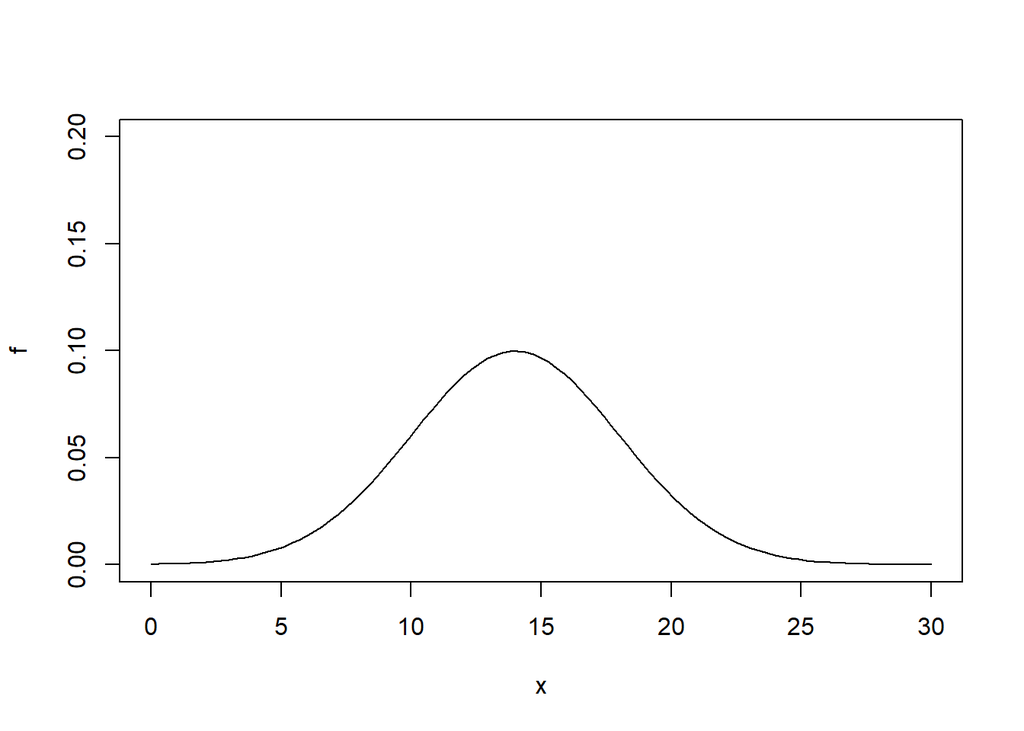

```r
plot(f, ylim=c(0,0.2), xlim=c(0, 30))
```

## 7

Suppose that $x\sim N(0,\sigma_x^2)$ and $w\sim N(0,\sigma_w^2)$ and $y=ax+w$. If w and x are independent, what is mean and covariance matrix for the Gaussian vector $z=[x,y]^T$? Hint: Note that $E[z]$ should be a 2D column vector and $var(z)$ should be a 2x2 matrix.

$$z=[x,y]^T$$
$$[E(x), E(\omega)]^T = [0, 0]^T$$
$$var(z)= \begin{bmatrix}\sigma_x^2&cov(x,y)\\cov(x,y)&var(y)\end{bmatrix}$$